# Red Wine Quality Project

Leo Tay

08 February, 2016

# Introduction:

Objective of the project is to determine which variables affect the quality of red wines and, if the variables affect each other. Dataset consists of 1599 red wines rated from 1 (Very Bad) to 10 (Very Excellent) quality. Each red wine has 11 chemical properties/variables.

# Univariate Plots Section

```
## [1] 1599   12
```

```
## 'data.frame':    1599 obs. of  12 variables:
##  $ fixed.acidity       : num  7.4 7.8 7.8 11.2 7.4 7.4 7.9 7.3 7.8 7.5 ...
##  $ volatile.acidity    : num  0.7 0.88 0.76 0.28 0.7 0.66 0.6 0.65 0.58 0.5 ...
##  $ citric.acid         : num  0 0 0.04 0.56 0 0 0.06 0 0.02 0.36 ...
##  $ residual.sugar      : num  1.9 2.6 2.3 1.9 1.9 1.8 1.6 1.2 2 6.1 ...
##  $ chlorides           : num  0.076 0.098 0.092 0.075 0.076 0.075 0.069 0.065 0.073 0.071 ...
##  $ free.sulfur.dioxide : num  11 25 15 17 11 13 15 15 9 17 ...
##  $ total.sulfur.dioxide: num  34 67 54 60 34 40 59 21 18 102 ...
##  $ density             : num  0.998 0.997 0.997 0.998 0.998 ...
##  $ pH                  : num  3.51 3.2 3.26 3.16 3.51 3.51 3.3 3.39 3.36 3.35 ...
##  $ sulphates           : num  0.56 0.68 0.65 0.58 0.56 0.56 0.46 0.47 0.57 0.8 ...
##  $ alcohol             : num  9.4 9.8 9.8 9.8 9.4 9.4 9.4 10 9.5 10.5 ...
##  $ quality             : int  5 5 5 6 5 5 5 7 7 5 ...
```

Dataset consists of approximately 1600 observations with 12 variables.

```
##  fixed.acidity   volatile.acidity  citric.acid    residual.sugar
##  Min.   : 4.60   Min.   :0.1200   Min.   :0.000   Min.   : 0.900
##  1st Qu.: 7.10   1st Qu.:0.3900   1st Qu.:0.090   1st Qu.: 1.900
##  Median : 7.90   Median :0.5200   Median :0.260   Median : 2.200
##  Mean   : 8.32   Mean   :0.5278   Mean   :0.271   Mean   : 2.539
##  3rd Qu.: 9.20   3rd Qu.:0.6400   3rd Qu.:0.420   3rd Qu.: 2.600
##  Max.   :15.90   Max.   :1.5800   Max.   :1.000   Max.   :15.500
##    chlorides       free.sulfur.dioxide total.sulfur.dioxide
##  Min.   :0.01200   Min.   : 1.00       Min.   :  6.00
##  1st Qu.:0.07000   1st Qu.: 7.00       1st Qu.: 22.00
##  Median :0.07900   Median :14.00       Median : 38.00
##  Mean   :0.08747   Mean   :15.87       Mean   : 46.47
##  3rd Qu.:0.09000   3rd Qu.:21.00       3rd Qu.: 62.00
##  Max.   :0.61100   Max.   :72.00       Max.   :289.00
##     density             pH          sulphates         alcohol
##  Min.   :0.9901   Min.   :2.740   Min.   :0.3300   Min.   : 8.40
##  1st Qu.:0.9956   1st Qu.:3.210   1st Qu.:0.5500   1st Qu.: 9.50
##  Median :0.9968   Median :3.310   Median :0.6200   Median :10.20
##  Mean   :0.9967   Mean   :3.311   Mean   :0.6581   Mean   :10.42
##  3rd Qu.:0.9978   3rd Qu.:3.400   3rd Qu.:0.7300   3rd Qu.:11.10
##  Max.   :1.0037   Max.   :4.010   Max.   :2.0000   Max.   :14.90
##     quality
##  Min.   :3.000
##  1st Qu.:5.000
##  Median :6.000
##  Mean   :5.636
##  3rd Qu.:6.000
##  Max.   :8.000
```

Summary statistics for the variables in the dataset.

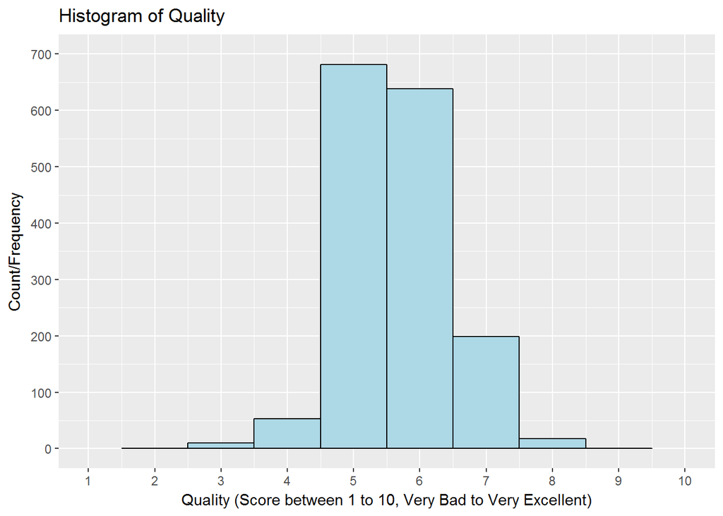

From the histogram, we can see that there are no ratings from 1 to 2 and 9 to 10, suggesting that while no wines were really bad, none were really good too (Subjective evaluation of quality). Based on the above, we can assume that the better/best quality range is 7 to 8.

# Histograms of remaining variables

Create histograms of remaining variables to find out if there are any interesting results.

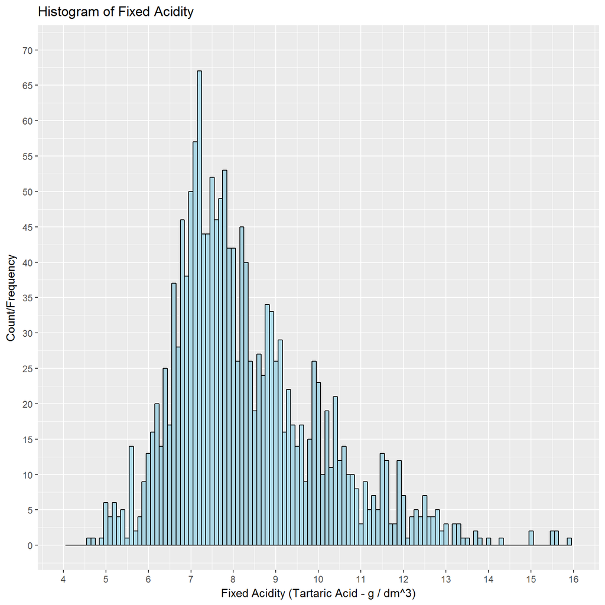

Histogram seems to be near normal distribution. Some outliers were noticed but as they are located near the remaining data, they will be included. Certain values have 0 counts suggesting that they had no effects or less likely, the red wines did not have those values.

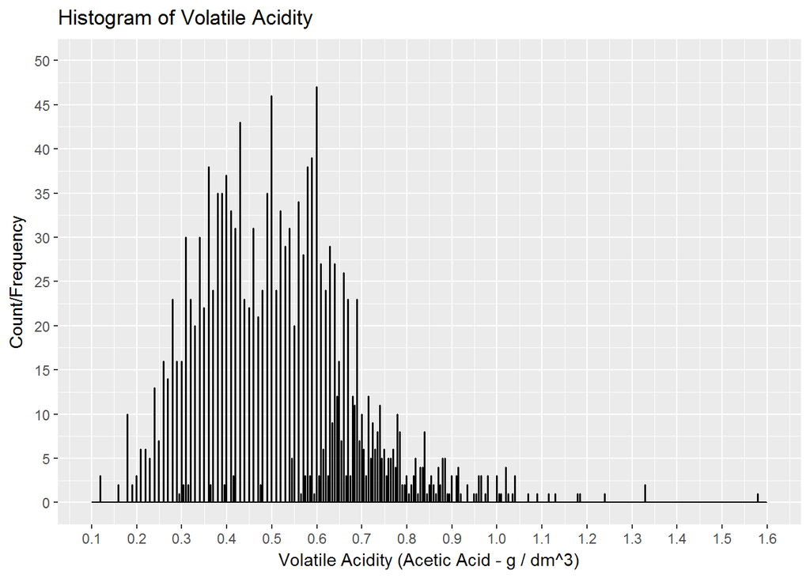

Histogram contained far-right outlier, will try transformaing it.

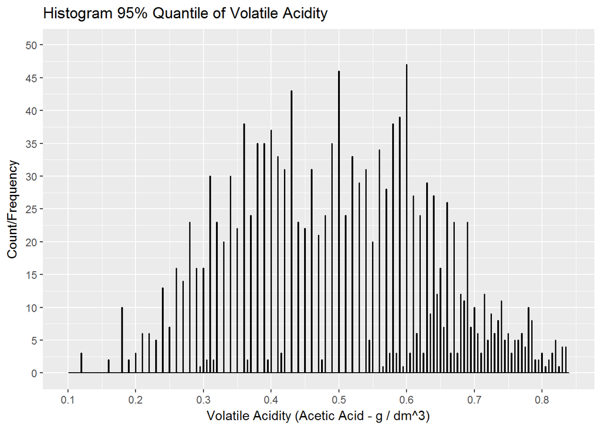

I decided to avoid using Log10 transformations as based on calculations, there are negative values instead, I opted to retain 95% quantile of the data. From it, the histogram seems to be near bi-modal with some values having 0 counts. (I had also encountered some issues while transforming using Log10 which I will elborate further in the reflections section.)

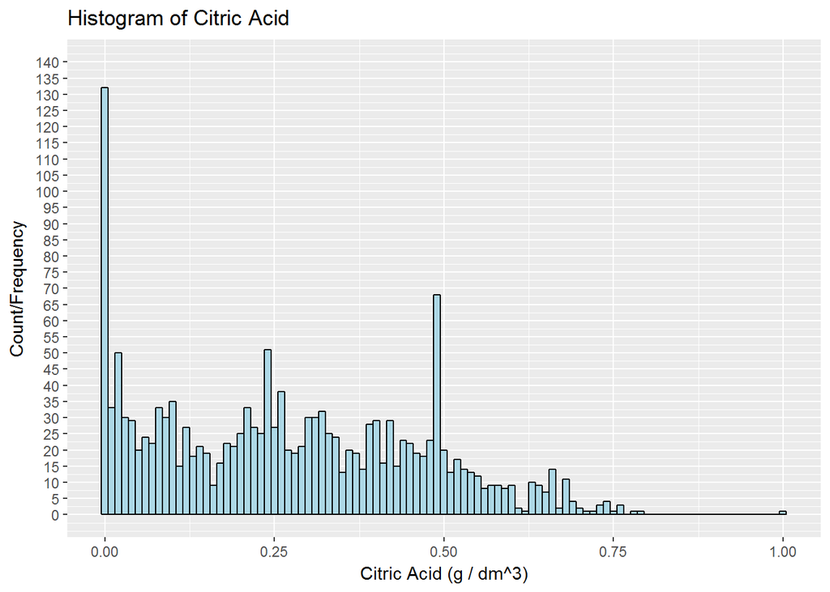

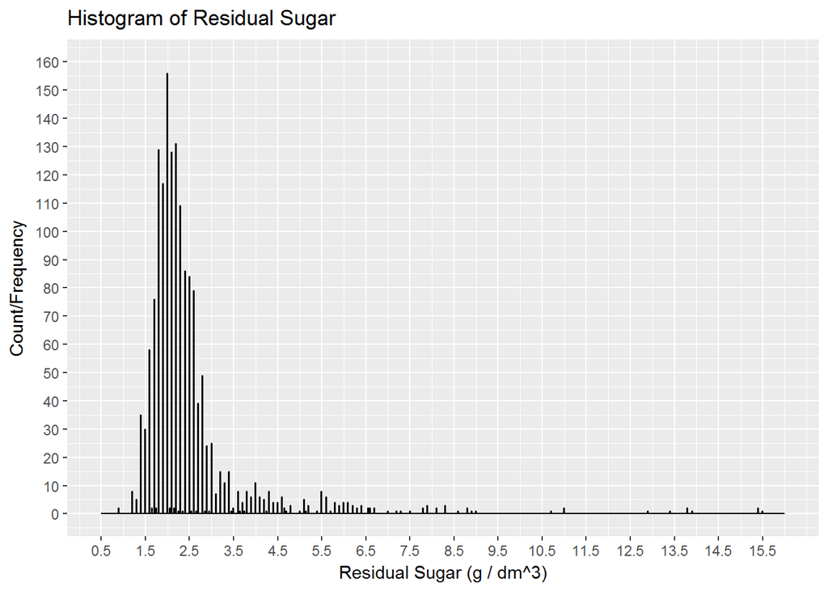

Multiple far-right outliers were observed and the histogram was difficult to read, will try to transform it.

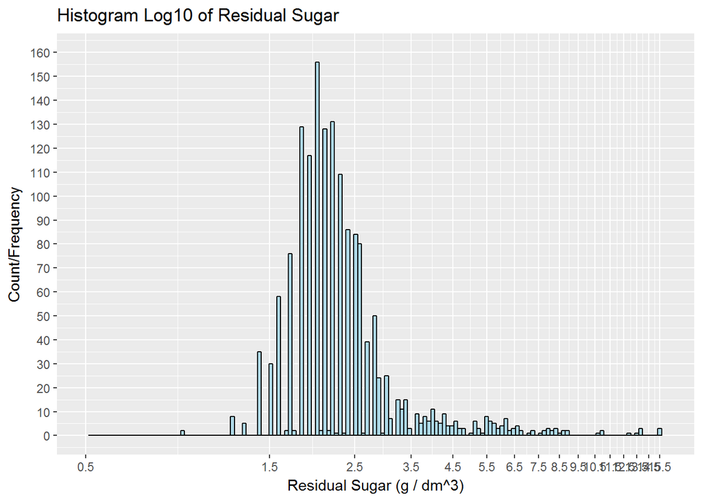

Log transformation of historgram seems similar to the above and is in a normal distribution. Majority of the data seems to end around residual sugar 9.0. There are still outliers but they do not appear to affect the distribution.

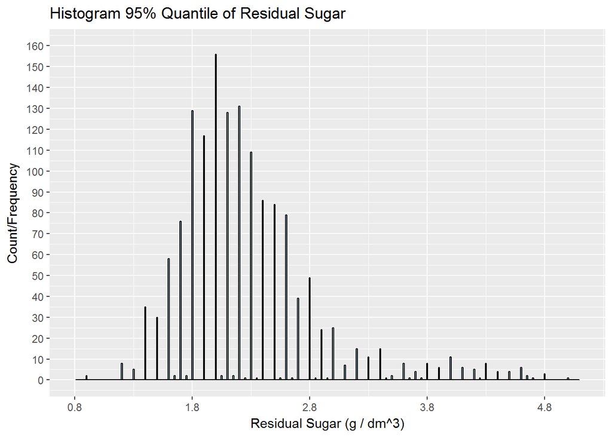

As the two histograms does not seem to be discernable, I decided to retain 95% quantile of the data to filter the outliers. Histogram is similar to a normal distribution with some trailing data on the right. I find it strange that the counts are low at certain residual sugar values such as 1.65, 1.75,2.05 in addition to others. Residual sugar value 2.00 has the highest count of all variables at 156. Being the most common value, I wonder if this will affect the quality.

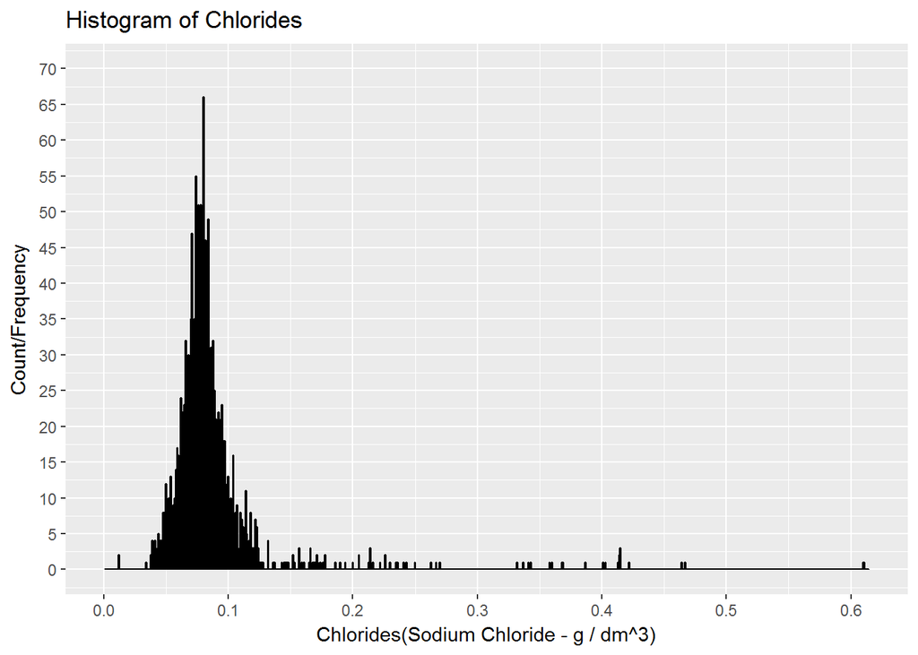

Far-right outliers were observed in the histogram. Plot is also clustered, making it hard to read.

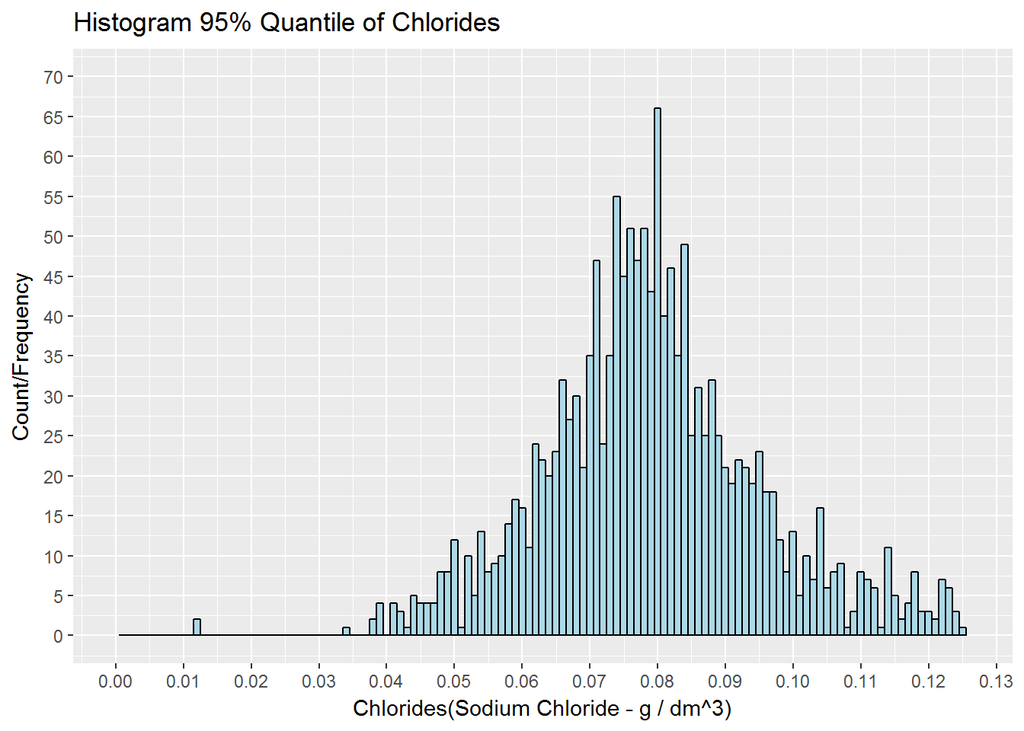

Histogram appears to be in near normal distribution. I wonder why there is a gap between the first count at value 0.012 to 0.034. Perhaps no red wines were created at those values.

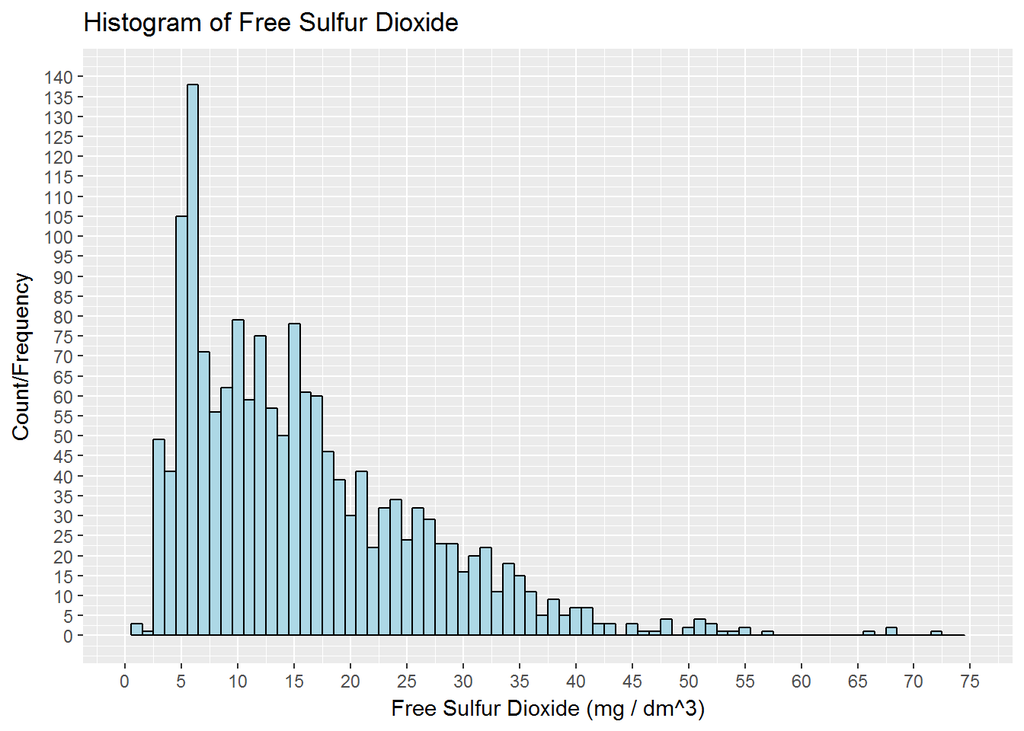

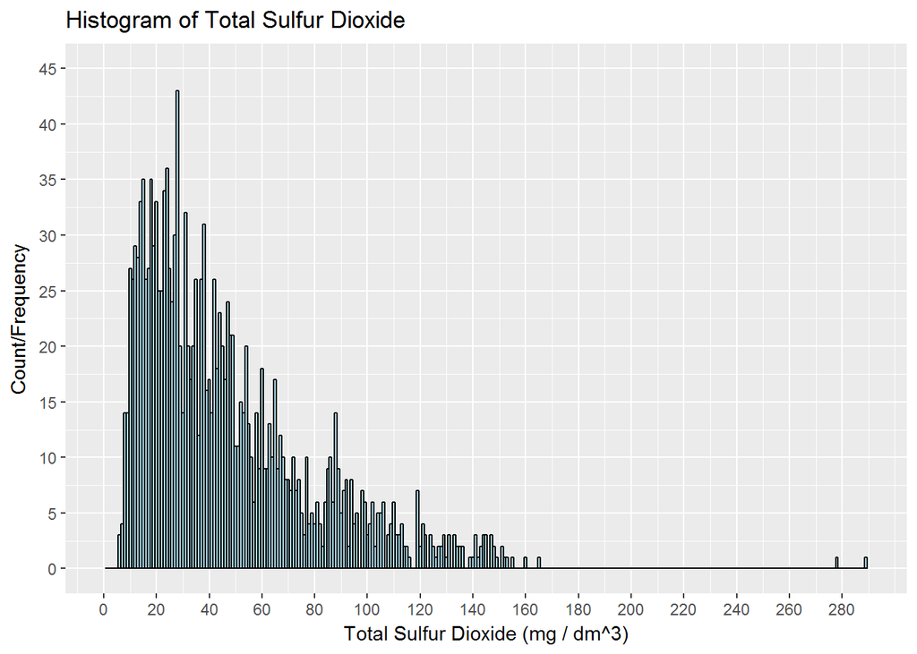

Far-right outliers were observed for the total sulfur dioxide histogram.

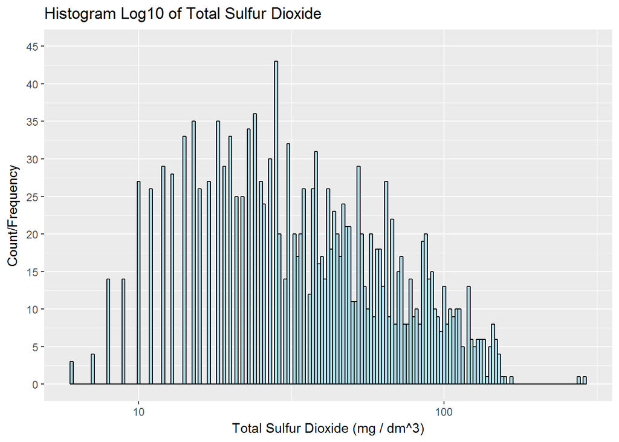

Performing a log10 scale on total sulfur dioxide, the historgram seems to be near a rounded normal distribution. It appears that values prior to 50 contained more 0 counts.

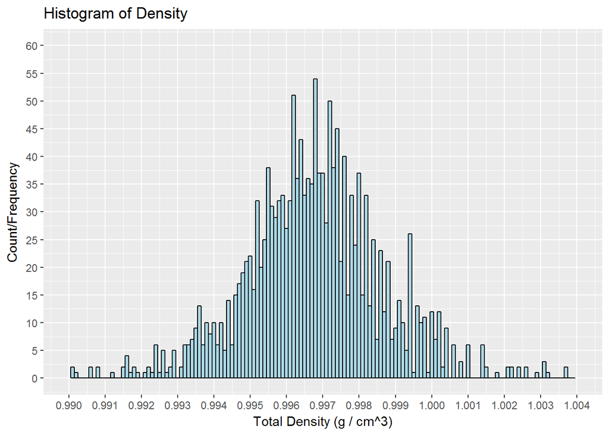

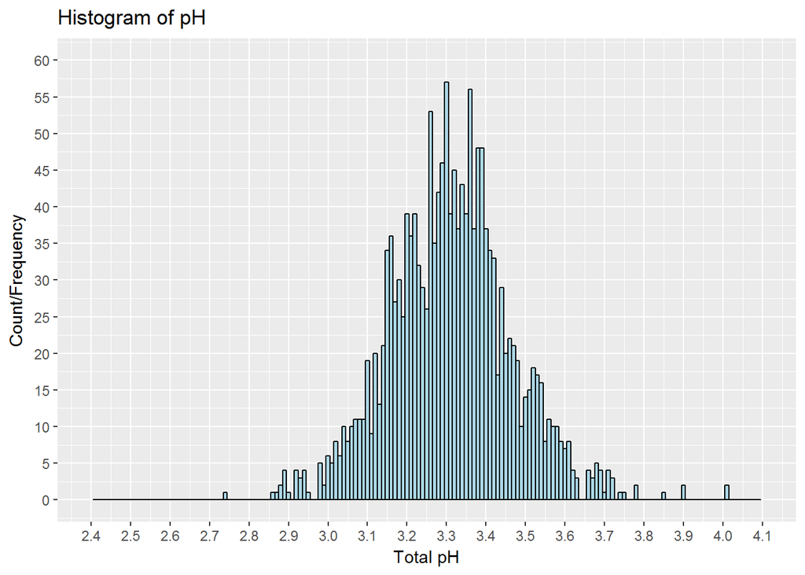

Histogram seems to be similar to a normal distribution. There are 0 counts where pH is 2.96, 2.97, 3.64 and, 3.65. This suggests that the four pH values might not be suitable for creating red wines.

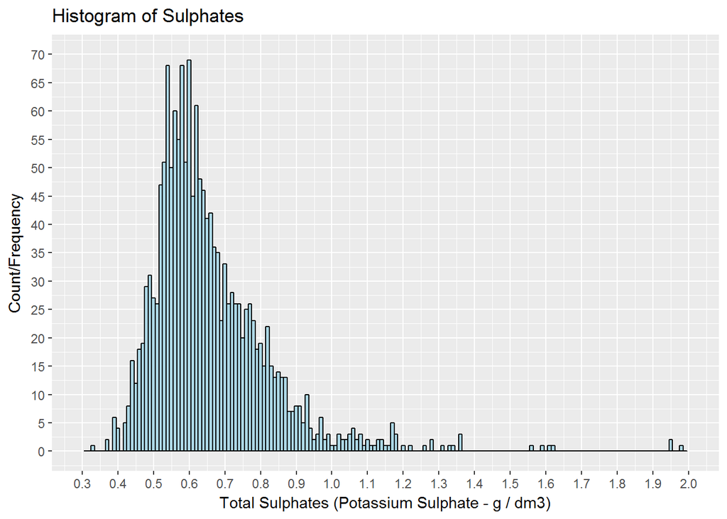

Histogram seems to be near normal distribution trailing to the right with far-right outliers. Outliers are retained as they did not affect the readability of the histogram. 0 count was noted where sulphates is at 0.41.

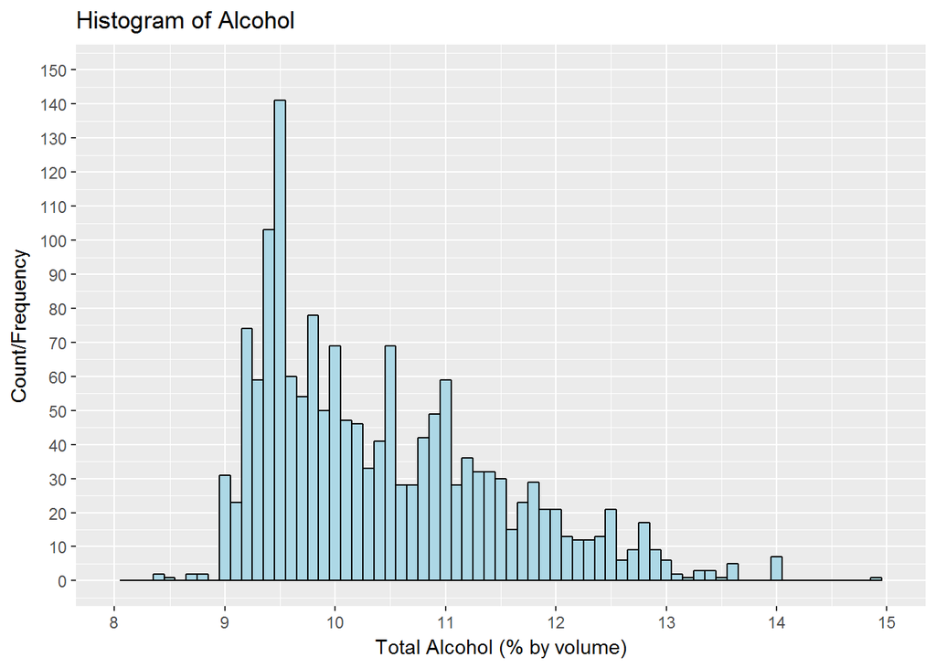

### Summary

It will be interesting to see how they affect quality (If any).

# Univariate Analysis

### What is the structure of your dataset?

No categorical variables were noticed in the dataset.

### What is/are the main feature(s) of interest in your dataset?

Main features are quality and Residual Sugar. Main goal is to determine what affects the quality of red wines. As Residual Sugar has the highest occurence among the wines, it seems logical that it in combination with other variables affect the quality.

### What other features in the dataset do you think will help support your investigation into your feature(s) of interest?

Based on my understanding, it seems that all the variables in the dataset affect the quality to some degree, be it taste, smell, health benefits or each other.

### Did you create any new variables from existing variables in the dataset?

No new variables were created as it will be hard to aggregate them into a total score of the variables.

### Of the features you investigated, were there any unusual distributions? Did you perform any operations on the data to tidy, adjust, or change the form of the data? If so, why did you do this?

Majority of the variables were in near-normal distributions. Volatile Acidity seemed to be in a bi-modal distribution. Outliers were observed for all variables.

# Bivariate Plots Section

```
##                      fixed.acidity volatile.acidity citric.acid
## fixed.acidity           1.00000000     -0.256130895  0.67170343
## volatile.acidity       -0.25613089      1.000000000 -0.55249568
## citric.acid             0.67170343     -0.552495685  1.00000000
## residual.sugar          0.11477672      0.001917882  0.14357716
## chlorides               0.09370519      0.061297772  0.20382291
## free.sulfur.dioxide    -0.15379419     -0.010503827 -0.06097813
## total.sulfur.dioxide   -0.11318144      0.076470005  0.03553302
## density                 0.66804729      0.022026232  0.36494718
## pH                     -0.68297819      0.234937294 -0.54190414
## sulphates               0.18300566     -0.260986685  0.31277004
## alcohol                -0.06166827     -0.202288027  0.10990325
## quality                 0.12405165     -0.390557780  0.22637251
##                      residual.sugar    chlorides free.sulfur.dioxide
## fixed.acidity           0.114776724  0.093705186        -0.153794193
## volatile.acidity        0.001917882  0.061297772        -0.010503827
## citric.acid             0.143577162  0.203822914        -0.060978129
## residual.sugar          1.000000000  0.055609535         0.187048995
## chlorides               0.055609535  1.000000000         0.005562147
## free.sulfur.dioxide     0.187048995  0.005562147         1.000000000
## total.sulfur.dioxide    0.203027882  0.047400468         0.667666450
## density                 0.355283371  0.200632327        -0.021945831
## pH                     -0.085652422 -0.265026131         0.070377499
## sulphates               0.005527121  0.371260481         0.051657572
## alcohol                 0.042075437 -0.221140545        -0.069408354
## quality                 0.013731637 -0.128906560        -0.050656057
##                      total.sulfur.dioxide     density          pH
## fixed.acidity                 -0.11318144  0.66804729 -0.68297819
## volatile.acidity               0.07647000  0.02202623  0.23493729
## citric.acid                    0.03553302  0.36494718 -0.54190414
## residual.sugar                 0.20302788  0.35528337 -0.08565242
## chlorides                      0.04740047  0.20063233 -0.26502613
## free.sulfur.dioxide            0.66766645 -0.02194583  0.07037750
## total.sulfur.dioxide           1.00000000  0.07126948 -0.06649456
## density                        0.07126948  1.00000000 -0.34169933
## pH                            -0.06649456 -0.34169933  1.00000000
## sulphates                      0.04294684  0.14850641 -0.19664760
## alcohol                       -0.20565394 -0.49617977  0.20563251
## quality                       -0.18510029 -0.17491923 -0.05773139
##                         sulphates     alcohol     quality
## fixed.acidity         0.183005664 -0.06166827  0.12405165
## volatile.acidity     -0.260986685 -0.20228803 -0.39055778
## citric.acid           0.312770044  0.10990325  0.22637251
## residual.sugar        0.005527121  0.04207544  0.01373164
## chlorides             0.371260481 -0.22114054 -0.12890656
## free.sulfur.dioxide   0.051657572 -0.06940835 -0.05065606
## total.sulfur.dioxide  0.042946836 -0.20565394 -0.18510029
## density               0.148506412 -0.49617977 -0.17491923
## pH                   -0.196647602  0.20563251 -0.05773139
## sulphates             1.000000000  0.09359475  0.25139708
## alcohol               0.093594750  1.00000000  0.47616632
## quality               0.251397079  0.47616632  1.00000000
```

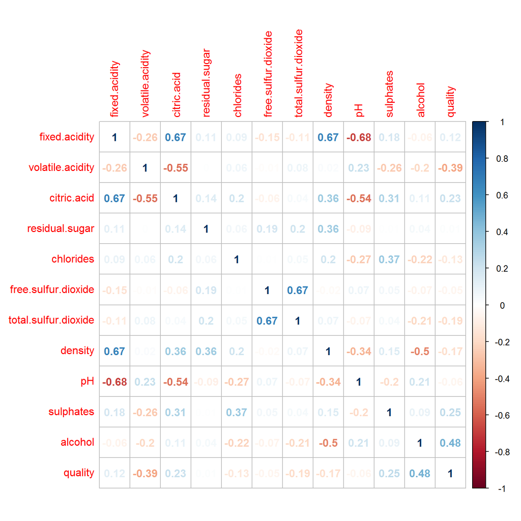

From the above correlation table and plot matrix, we can see that quality has positive relations with:

- Alcohol: 0.48
- Sulphates: 0.25
- Citric Acid: 0.23
- Fixed Acidity: 0.12
- Residual Sugar: 0.01

It’s worth looking further at how the above variables affect quality.

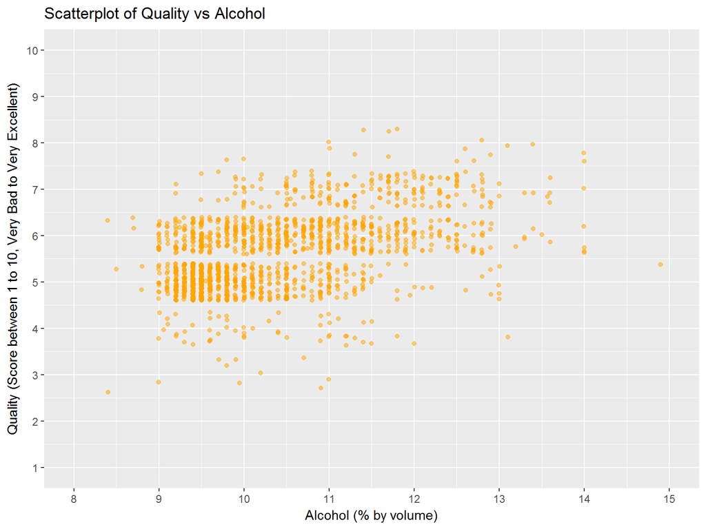

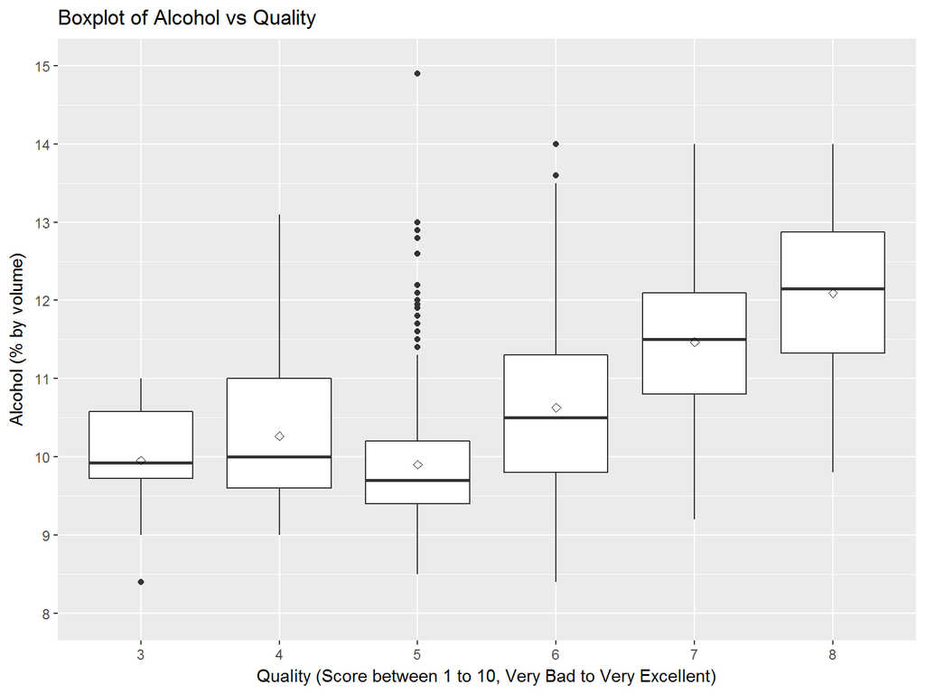

Quality vs Alcohol: There seems to be a relationship where increasing alcohol increases quality also however, effect seems to stop around where alcohol is 14. The increase in quality also seems to be limited as most red wines are located between quality 5 to 6. Quality 8 was first captured where alcohol is 9.8 and ended at 14.

```
## # A tibble: 65 × 5
##    alcohol quality_mean quality_median quality_max     n
##      <dbl>        <dbl>          <dbl>       <int> <int>
## 1      9.8     5.294872            5.0           8    78
## 2     10.0     5.597015            6.0           8    67
## 3     11.0     5.745763            6.0           8    59
## 4     11.3     6.062500            6.0           8    32
## 5     11.4     5.718750            6.0           8    32
## 6     11.7     6.608696            7.0           8    23
## 7     11.8     6.275862            6.0           8    29
## 8     12.5     6.523810            6.0           8    21
## 9     12.6     6.500000            6.5           8     6
## 10    12.7     6.444444            6.0           8     9
## # ... with 55 more rows
```

```
## rwq$quality: 3
##    Min. 1st Qu.  Median    Mean 3rd Qu.    Max.
##   8.400   9.725   9.925   9.955  10.580  11.000
## --------------------------------------------------------
## rwq$quality: 4
##    Min. 1st Qu.  Median    Mean 3rd Qu.    Max.
##    9.00    9.60   10.00   10.27   11.00   13.10
## --------------------------------------------------------
## rwq$quality: 5
##    Min. 1st Qu.  Median    Mean 3rd Qu.    Max.
##     8.5     9.4     9.7     9.9    10.2    14.9
## --------------------------------------------------------
## rwq$quality: 6
##    Min. 1st Qu.  Median    Mean 3rd Qu.    Max.
##    8.40    9.80   10.50   10.63   11.30   14.00
## --------------------------------------------------------
## rwq$quality: 7
##    Min. 1st Qu.  Median    Mean 3rd Qu.    Max.
##    9.20   10.80   11.50   11.47   12.10   14.00
## --------------------------------------------------------
## rwq$quality: 8
##    Min. 1st Qu.  Median    Mean 3rd Qu.    Max.
##    9.80   11.32   12.15   12.09   12.88   14.00
```

To achieve quality 8 red wines, the average alcohol % should be 12.09.

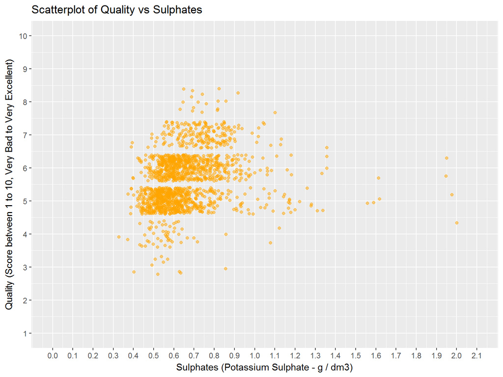

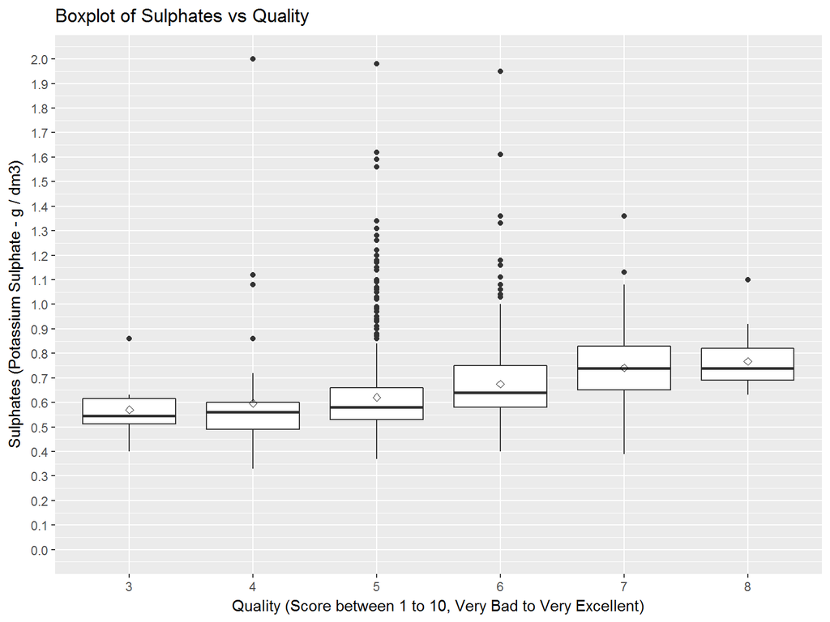

Quality vs Sulphates: Similar to alcohol, increasing the amount sulphates also increases quality but the effect drops beyond 1.0 sulphates. However, majority of the quality also falls between 5 to 6. Quality of 8 was first captured where sulphates is 0.63 and stopped at 1.10.

```
## # A tibble: 96 × 5
##    sulphates quality_mean quality_median quality_max     n
##        <dbl>        <dbl>          <dbl>       <int> <int>
## 1       0.63     5.604167              6           8    48
## 2       0.65     5.951220              6           8    41
## 3       0.69     6.217391              6           8    23
## 4       0.70     5.939394              6           8    33
## 5       0.72     5.928571              6           8    28
## 6       0.74     6.153846              6           8    26
## 7       0.76     6.520000              7           8    25
## 8       0.82     6.409091              6           8    22
## 9       0.86     6.000000              6           8    13
## 10      0.92     6.800000              7           8     5
## # ... with 86 more rows
```

```
## rwq$quality: 3
##    Min. 1st Qu.  Median    Mean 3rd Qu.    Max.
##  0.4000  0.5125  0.5450  0.5700  0.6150  0.8600
## --------------------------------------------------------
## rwq$quality: 4
##    Min. 1st Qu.  Median    Mean 3rd Qu.    Max.
##  0.3300  0.4900  0.5600  0.5964  0.6000  2.0000
## --------------------------------------------------------
## rwq$quality: 5
##    Min. 1st Qu.  Median    Mean 3rd Qu.    Max.
##   0.370   0.530   0.580   0.621   0.660   1.980
## --------------------------------------------------------
## rwq$quality: 6
##    Min. 1st Qu.  Median    Mean 3rd Qu.    Max.
##  0.4000  0.5800  0.6400  0.6753  0.7500  1.9500
## --------------------------------------------------------
## rwq$quality: 7
##    Min. 1st Qu.  Median    Mean 3rd Qu.    Max.
##  0.3900  0.6500  0.7400  0.7413  0.8300  1.3600
## --------------------------------------------------------
## rwq$quality: 8
##    Min. 1st Qu.  Median    Mean 3rd Qu.    Max.
##  0.6300  0.6900  0.7400  0.7678  0.8200  1.1000
```

To achieve quality 8 red wines, the average sulphates level should be 0.7678.

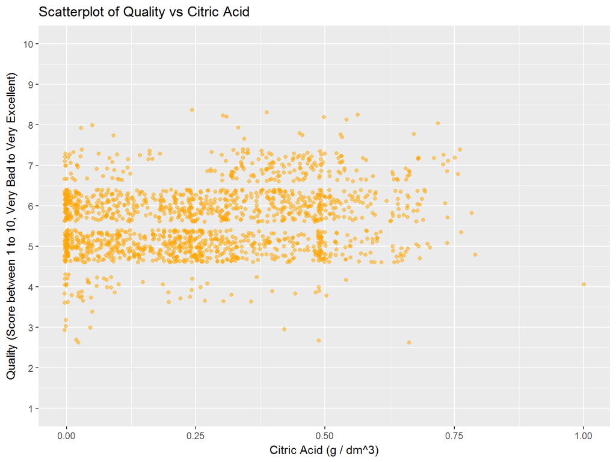

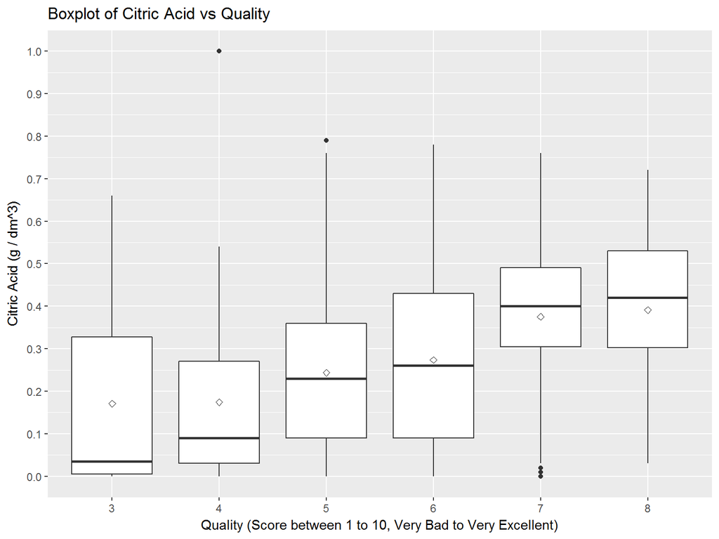

Quality vs Citric Acid: Relationship seems to be minor as citric acid value 0.00 has also been captured on better qualities. Quality of 8 was captured from citirc acid is 0.03 to 0.72.

```
## # A tibble: 80 × 5
##    citric.acid quality_mean quality_median quality_max     n
##          <dbl>        <dbl>          <dbl>       <int> <int>
## 1         0.03     5.333333            5.0           8    30
## 2         0.05     5.200000            5.0           8    20
## 3         0.09     5.566667            5.5           8    30
## 4         0.24     5.490196            6.0           8    51
## 5         0.30     5.733333            6.0           8    30
## 6         0.31     5.800000            6.0           8    30
## 7         0.33     5.800000            6.0           8    25
## 8         0.34     6.166667            6.0           8    24
## 9         0.39     6.071429            6.0           8    28
## 10        0.45     6.181818            6.0           8    22
## # ... with 70 more rows
```

```
## rwq$quality: 3
##    Min. 1st Qu.  Median    Mean 3rd Qu.    Max.
##  0.0000  0.0050  0.0350  0.1710  0.3275  0.6600
## --------------------------------------------------------
## rwq$quality: 4
##    Min. 1st Qu.  Median    Mean 3rd Qu.    Max.
##  0.0000  0.0300  0.0900  0.1742  0.2700  1.0000
## --------------------------------------------------------
## rwq$quality: 5
##    Min. 1st Qu.  Median    Mean 3rd Qu.    Max.
##  0.0000  0.0900  0.2300  0.2437  0.3600  0.7900
## --------------------------------------------------------
## rwq$quality: 6
##    Min. 1st Qu.  Median    Mean 3rd Qu.    Max.
##  0.0000  0.0900  0.2600  0.2738  0.4300  0.7800
## --------------------------------------------------------
## rwq$quality: 7
##    Min. 1st Qu.  Median    Mean 3rd Qu.    Max.
##  0.0000  0.3050  0.4000  0.3752  0.4900  0.7600
## --------------------------------------------------------
## rwq$quality: 8
##    Min. 1st Qu.  Median    Mean 3rd Qu.    Max.
##  0.0300  0.3025  0.4200  0.3911  0.5300  0.7200
```

To achieve quality 8 red wines, the average citric acid level should be 0.3911.

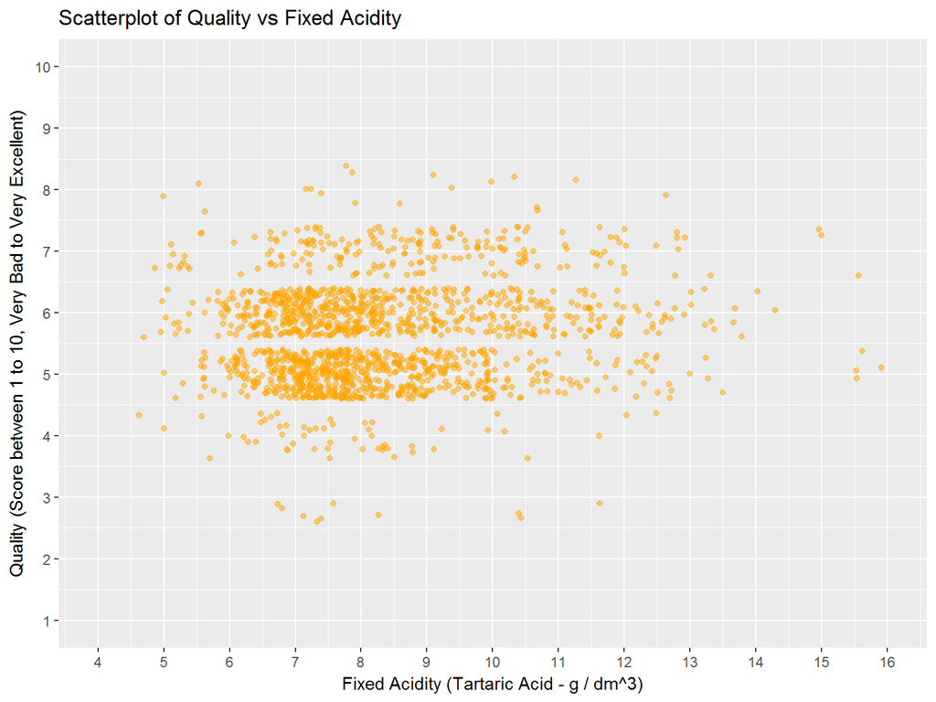

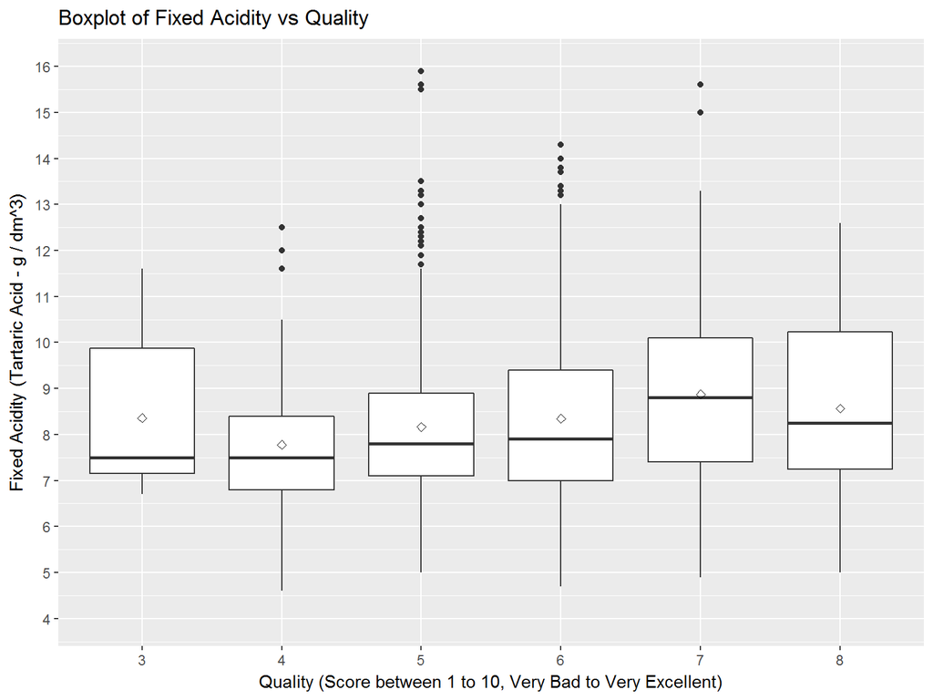

Quality vs Fixed Acidity: While quality 8 has been captured on certain fixed acidity values, the results are too spread out to say that increasing fixed acidity increases quality. Quality 8 was from fixed acidity is 5 to 12.6.

```
## # A tibble: 96 × 5
##    fixed.acidity quality_mean quality_median quality_max     n
##            <dbl>        <dbl>          <dbl>       <int> <int>
## 1            5.0     5.833333              6           8     6
## 2            5.5     8.000000              8           8     1
## 3            5.6     5.500000              5           8    14
## 4            7.2     5.701493              6           8    67
## 5            7.4     5.500000              5           8    44
## 6            7.8     5.528302              5           8    53
## 7            7.9     5.785714              6           8    42
## 8            8.6     5.481481              5           8    27
## 9            9.1     6.000000              6           8    29
## 10           9.4     6.058824              6           8    17
## # ... with 86 more rows
```

```
## rwq$quality: 3
##    Min. 1st Qu.  Median    Mean 3rd Qu.    Max.
##   6.700   7.150   7.500   8.360   9.875  11.600
## --------------------------------------------------------
## rwq$quality: 4
##    Min. 1st Qu.  Median    Mean 3rd Qu.    Max.
##   4.600   6.800   7.500   7.779   8.400  12.500
## --------------------------------------------------------
## rwq$quality: 5
##    Min. 1st Qu.  Median    Mean 3rd Qu.    Max.
##   5.000   7.100   7.800   8.167   8.900  15.900
## --------------------------------------------------------
## rwq$quality: 6
##    Min. 1st Qu.  Median    Mean 3rd Qu.    Max.
##   4.700   7.000   7.900   8.347   9.400  14.300
## --------------------------------------------------------
## rwq$quality: 7
##    Min. 1st Qu.  Median    Mean 3rd Qu.    Max.
##   4.900   7.400   8.800   8.872  10.100  15.600
## --------------------------------------------------------
## rwq$quality: 8
##    Min. 1st Qu.  Median    Mean 3rd Qu.    Max.
##   5.000   7.250   8.250   8.567  10.230  12.600
```

To achieve quality 8 red wines, the average fixed acidity level should be 8.567.

[figure not shown]

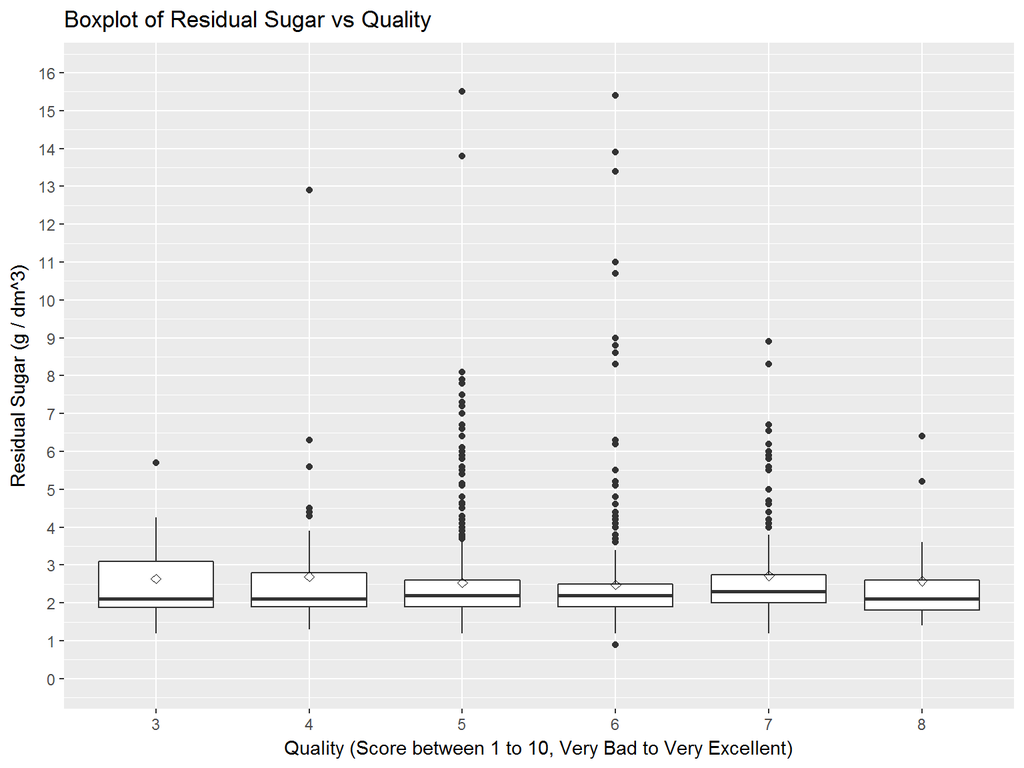

Quality vs Residual Sugar: No meaningful relationships were observed. Quality stopped increasing beyond residual sugar is 6.40. Quality 8 was captured from residual sugar is 1.40 to 6.40.

```
## # A tibble: 91 × 5
##    residual.sugar quality_mean quality_median quality_max     n
##             <dbl>        <dbl>          <dbl>       <int> <int>
## 1             1.4     5.685714              6           8    35
## 2             1.7     5.710526              6           8    76
## 3             1.8     5.697674              6           8   129
## 4             1.9     5.564103              6           8   117
## 5             2.0     5.570513              6           8   156
## 6             2.2     5.633588              6           8   131
## 7             2.3     5.596330              6           8   109
## 8             2.5     5.690476              6           8    84
## 9             2.6     5.594937              5           8    79
## 10            2.8     5.795918              6           8    49
## # ... with 81 more rows
```

```
## rwq$quality: 3
##    Min. 1st Qu.  Median    Mean 3rd Qu.    Max.
##   1.200   1.875   2.100   2.635   3.100   5.700
## --------------------------------------------------------
## rwq$quality: 4
##    Min. 1st Qu.  Median    Mean 3rd Qu.    Max.
##   1.300   1.900   2.100   2.694   2.800  12.900
## --------------------------------------------------------
## rwq$quality: 5
##    Min. 1st Qu.  Median    Mean 3rd Qu.    Max.
##   1.200   1.900   2.200   2.529   2.600  15.500
## --------------------------------------------------------
## rwq$quality: 6
##    Min. 1st Qu.  Median    Mean 3rd Qu.    Max.
##   0.900   1.900   2.200   2.477   2.500  15.400
## --------------------------------------------------------
## rwq$quality: 7
##    Min. 1st Qu.  Median    Mean 3rd Qu.    Max.
##   1.200   2.000   2.300   2.721   2.750   8.900
## --------------------------------------------------------
## rwq$quality: 8
##    Min. 1st Qu.  Median    Mean 3rd Qu.    Max.
##   1.400   1.800   2.100   2.578   2.600   6.400
```

To achieve quality 8 red wines, the average residual sugar level should be 2.578.

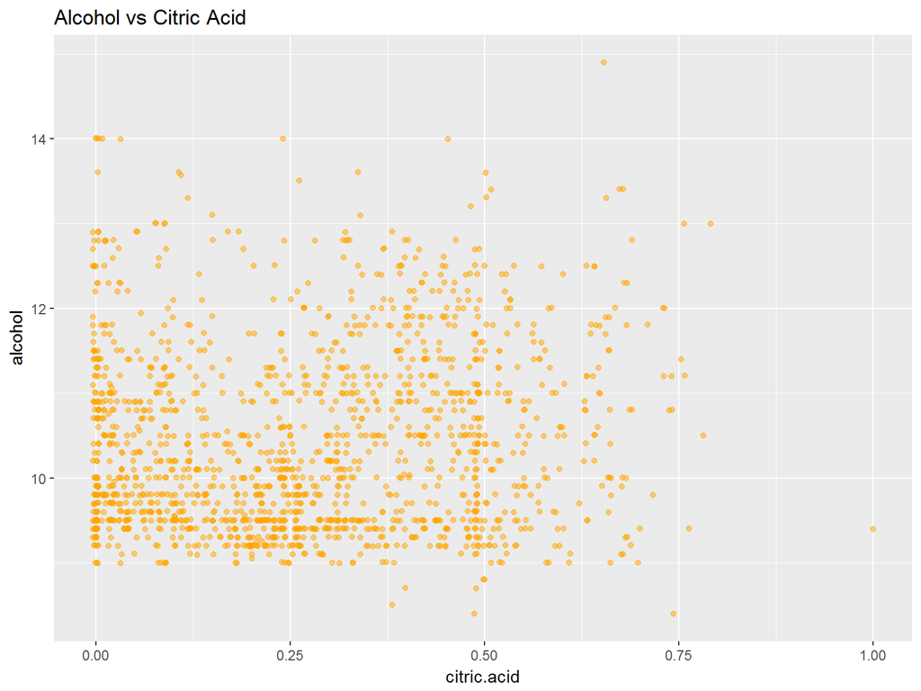

No visible increase in alcohol could be seen by increasing citric acid.

# Bivariate Analysis

### Talk about some of the relationships you observed in this part of the investigation. How did the feature(s) of interest vary with other features in the dataset?

Alcohol has moderate correlation with quality while Sulphates, Citric Acid, Fixed Acidity and, Residual Sugar has low correlations.

Being the highest correlation observed, I was expecting the Quality vs Alcohol relationship where increasing alcohol increases quality to be more prominent. From the scatterplot, the increase was not as expected with alcohol values appearing on different quality values however, it was only between alcohol 9.8 to 14 that quality 8 started to appear more frequently.

For Sulpahtes, a similar pattern was observed where increasing between 0.63 to 1.10 results in quality of 8.

For Citric Acid, Fixed Acidity and Residual Sugar, quality 8 have been captured across their respective scales hence, increasing them should not result in higher quality values.

Throughout comparing Quality with Sulphates, Citric Acid, Fixed Acidity and, Residual Sugar, the majority of quality was found to be between 5 to 6.

### Did you observe any interesting relationships between the other features (not the main feature(s) of interest)?

Alcohol seems to have a relationship with Citric Acid however after creating the scatterplot, increasing citric acid does not seem to increase alcohol.

### What was the strongest relationship you found?

Strongest relationship would still be Alcohol vs Quality. The plot has shown that while better quality wines have appeared with lower alcohol values, it is only when increasing alcohol that we see more wines with better quality.